# sarima-garch

Indra Mahib Zuhair Riyanto

2024-10-26

```r
library(ggplot2)
library(tsibble)
library(tseries)
library(MASS)
library(forecast)
library(graphics)
library(TTR)
library(TSA)
library(dplyr)
library(FinTS)
library(fGarch)
library(rugarch)
```

## Data

```r
dt <- read.csv("D:\\IPB\\5\\MPDW\\project\\5 data\\april_september.csv")
head(dt)
```

```
##      Tanggal ID.Prasarana                          Prasarana
## 1 2023-04-01          AAP                        APT Pranoto
## 2 2023-04-01          AMQ                          Pattimura
## 3 2023-04-01          BDJ                     Syamsudin Noor
## 4 2023-04-01          BEJ                          Kalimarau
## 5 2023-04-01          BIK                     Frans Kaisiepo
## 6 2023-04-01          BKS Fatmawati Soekarno/Padang Kemiling
##   Penumpang.Berangkat Penumpang.Berangkat.Domestik
## 1                 823                          823
## 2                 637                          637
## 3                2578                         2578
## 4                 365                          365
## 5                 265                          265
## 6                 543                          543
##   Penumpang.Berangkat.Internasional Penumpang.Tiba Penumpang.Tiba.Domestik
```

[output cut: 20 more lines]

### Data Selection

```r
dt <- dt %>% filter(ID.Prasarana=="BPN") %>%
  select(Tanggal, Penumpang.Berangkat, Penumpang.Tiba) %>%
  rename(tanggal = Tanggal, brgkt = Penumpang.Berangkat, tiba = Penumpang.Tiba)
str(dt)
```

```
## 'data.frame':    542 obs. of  3 variables:
##  $ tanggal: chr  "2023-04-01" "2023-04-02" "2023-04-03" "2023-04-04" ...
##  $ brgkt  : int  4917 4189 4151 4738 5515 6257 5134 4956 5453 5851 ...
##  $ tiba   : int  4498 4226 4468 4494 4896 4708 4363 4275 5432 5488 ...
```

### Formatting

```r
dt$tanggal <- as.Date(dt$tanggal, format = "%Y-%m-%d")
```

## Eksplorasi

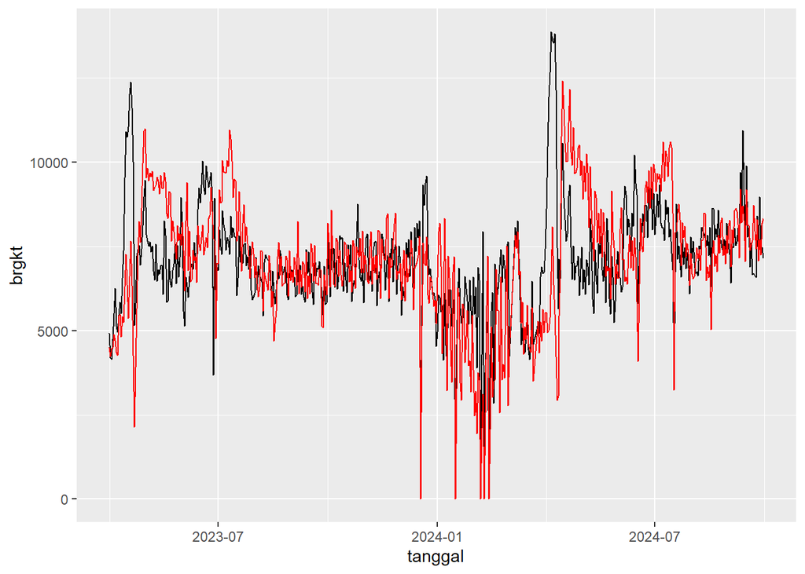

```r
ggplot(dt, aes(tanggal, brgkt)) +
  geom_line() +
  geom_line(aes(tanggal, tiba), color = "red")
```

Ada beberapa yang memiliki nilai 0. Perlu di telusuri mengapa hal ini terjadi.

```r
dt %>% filter(brgkt==0 | tiba==0)
```

```
##      tanggal brgkt tiba
## 1 2023-12-18     0    0
## 2 2024-01-16     0    0
## 3 2024-02-06     0    0
## 4 2024-02-09     0    0
## 5 2024-02-13     0    0
```

terdapat 5 data yang memiliki nilai 0. Tidak ada berita yang mengidikasikan bandara ditutup pada tanggal yang bersangkutan. Maka, data ini dianggap sebagai data yang hilang dan perlu diimputasi.

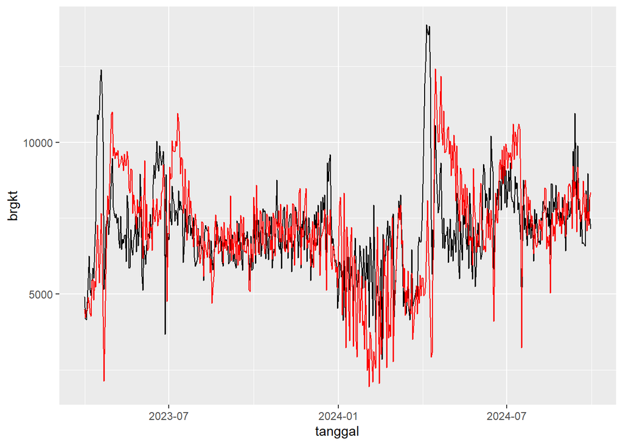

```r
# Imputasi dengan Median
#dt <- dt %>% mutate(brgkt = ifelse(brgkt==0, median(brgkt,na.rm=T), brgkt),
                   # tiba = ifelse(tiba==0, median(tiba,na.rm=T), tiba))

#Imputasi dengan average sebelum sesudah
for(i in 1:dim(dt)[1]){
  if(dt$brgkt[i]==0){
    dt$brgkt[i] <- (dt$brgkt[i-1] + dt$brgkt[i+1])/2
    dt$tiba[i] <- (dt$tiba[i-1] + dt$tiba[i+1])/2
  }
}

## Plot untuk cek
ggplot(dt, aes(tanggal, brgkt)) +
  geom_line() +
  geom_line(aes(tanggal, tiba), color = "red")
```

Sudah aman.

```r
dt$passenger <- dt$brgkt + dt$tiba
summary(dt)
```

```
##     tanggal               brgkt            tiba         passenger
##  Min.   :2023-04-01   Min.   : 2844   Min.   : 1944   Min.   : 5846
##  1st Qu.:2023-08-14   1st Qu.: 6238   1st Qu.: 6326   1st Qu.:12691
##  Median :2023-12-27   Median : 7000   Median : 7207   Median :14361
##  Mean   :2023-12-30   Mean   : 7127   Mean   : 7139   Mean   :14266
##  3rd Qu.:2024-05-17   3rd Qu.: 7762   3rd Qu.: 8195   3rd Qu.:16171
##  Max.   :2024-09-30   Max.   :13869   Max.   :12414   Max.   :22978
```

```r
write.csv(dt, "D:\\IPB\\5\\MPDW\\data\\passenger.csv")
```

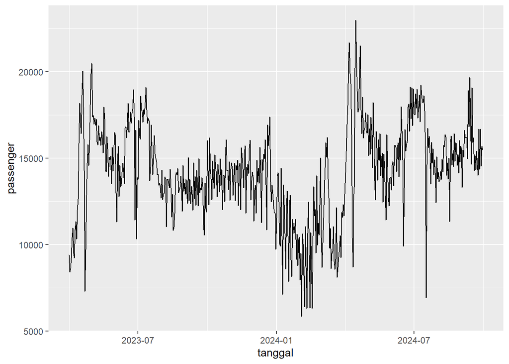

```r
ggplot(dt, aes(tanggal, passenger)) +
  geom_line()
```

Data yang kita miliki memiliki fluktuasi yang cukup tinggi. Ini mengingingidikasikan data yang kita miliki tidak stasioner.

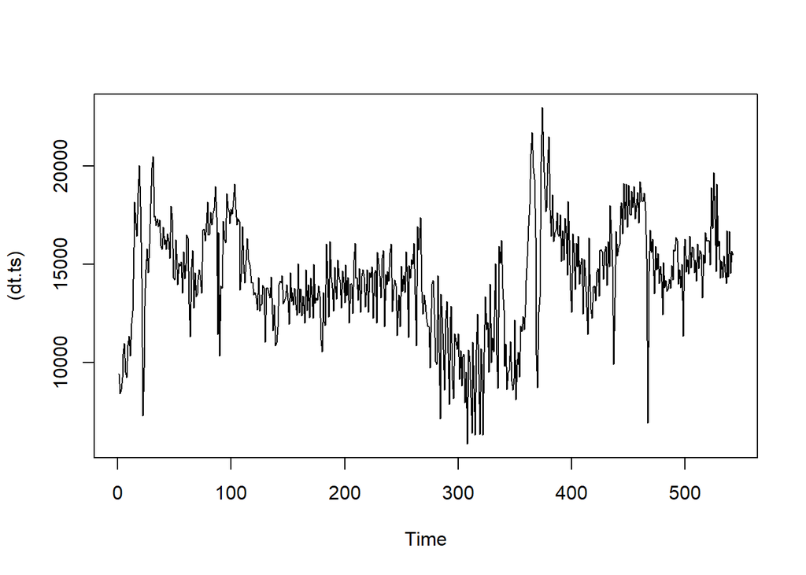

```r
dt.ts <- ts((dt$passenger))
plot((dt.ts))
```

### Train Test Split

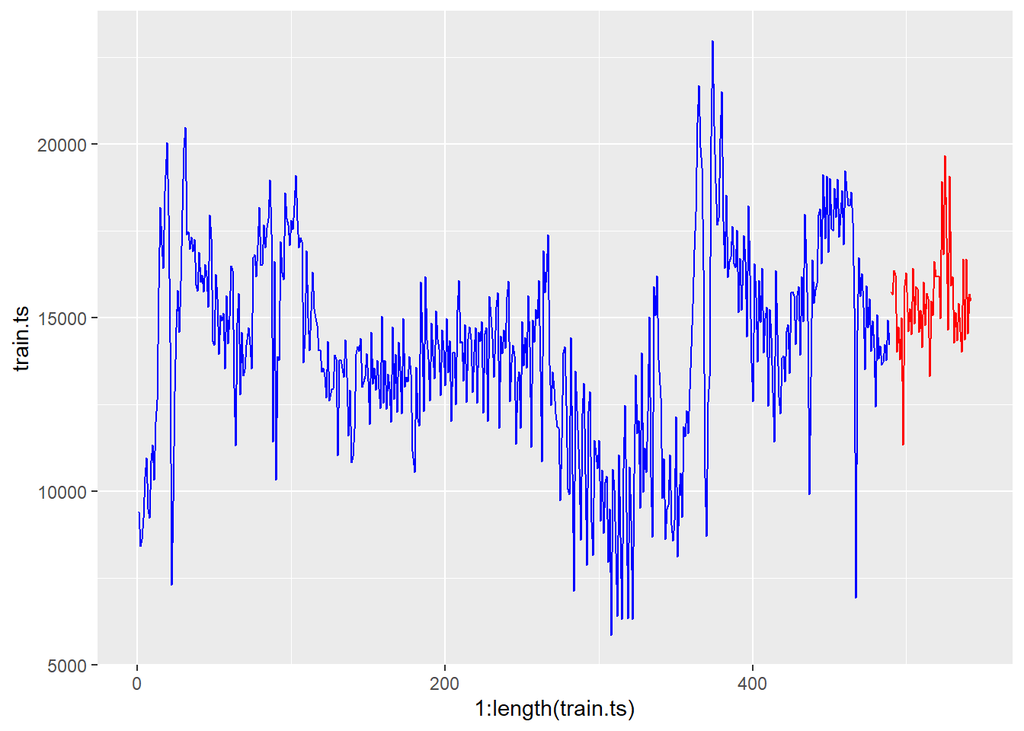

```r
train.ts <- dt.ts[1:(round(length(dt.ts)*0.90)+1)] %>% ts()
test.ts <- dt.ts[((round(length(dt.ts)*0.90)+2)):length(dt.ts)] %>% ts()

## plot data train and test
ggplot()+
  geom_line(aes(x=1:length(train.ts), y=train.ts), color="blue")+
  geom_line(aes(x=(1:length(test.ts)+length(train.ts)), y=test.ts), color="red")
```

train test split process sudah sesuai.

## Eksplorasi Train Data

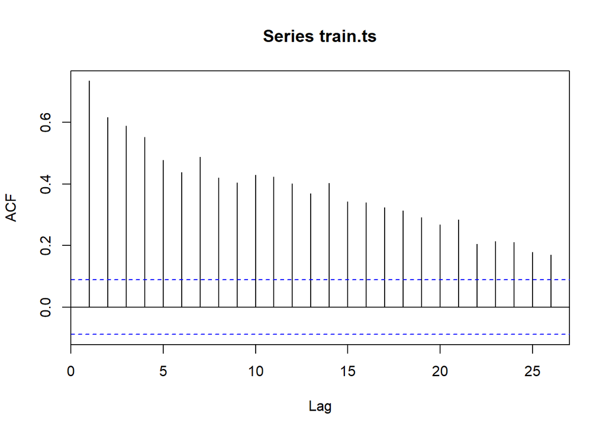

```r
acf(train.ts)
```

data yang kita miliki memiliki acf yang very slowly tails off mengindikasikan data yang tidak stasioner.

```r
adf.test(train.ts)
```

```
##
##  Augmented Dickey-Fuller Test
##
## data:  train.ts
## Dickey-Fuller = -4.0532, Lag order = 7, p-value = 0.01
## alternative hypothesis: stationary
```

Hasil adf.test menunjukan tolak H0 yang artinya data sudah stasioner. Walaupun begitu, kita akan tetap menganggap data tidak staisoner dalam rataan

```r
index.train <- 1:length(train.ts)
bc.train.ts <- boxcox(train.ts - (min(train.ts)-1) ~ index.train, lambda = seq(-2, 2, 0.1))
```

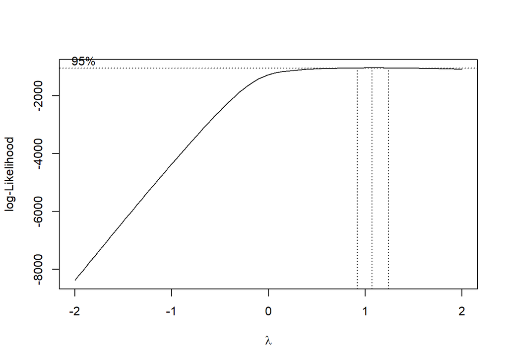

Boxcox mengandung nilai 1 yang mengindikasikan data yang kita miliki tidak memerlukan transformasi dan stasioner dalam ragam.

### Differencing

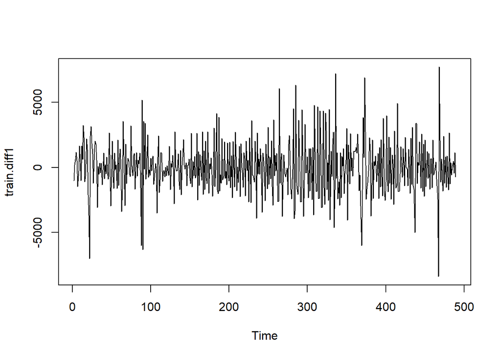

```r
train.diff1 <- diff(train.ts,lag=1)
plot(train.diff1)
```

hasil differencing menunjukan data yang kita miliki sudah stasioner dalam rataan.

```r
adf.test(train.diff1)
```

```
##
##  Augmented Dickey-Fuller Test
##
## data:  train.diff1
## Dickey-Fuller = -11.032, Lag order = 7, p-value = 0.01
## alternative hypothesis: stationary
```

Sudah stasioner dalam rataan.

```r
index.train.diff1 <- 1:length(train.diff1)
bc.train.diff1 <- boxcox(train.diff1 - (min(train.diff1)-1) ~ index.train.diff1, lambda = seq(-2, 2, 0.1))
```

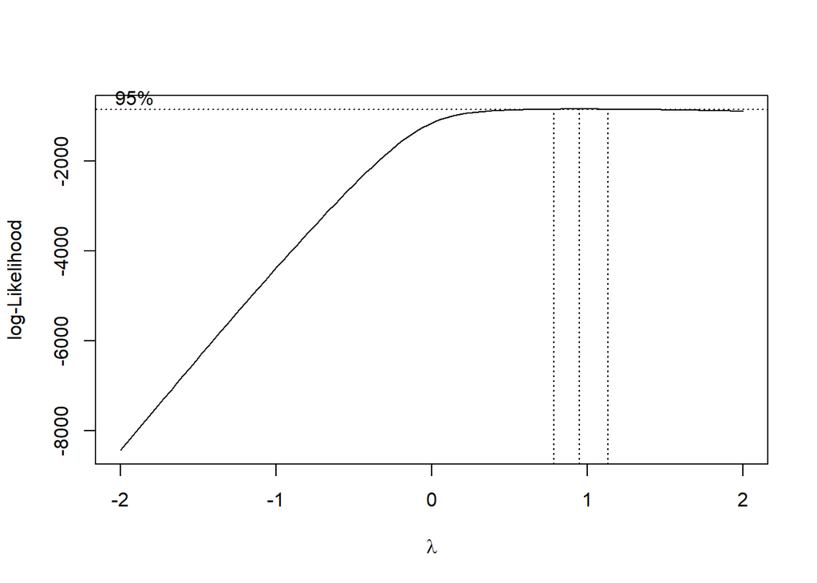

Boxcox mengandung angka 1 sehingga sudah tidak memerlukan transformasi.

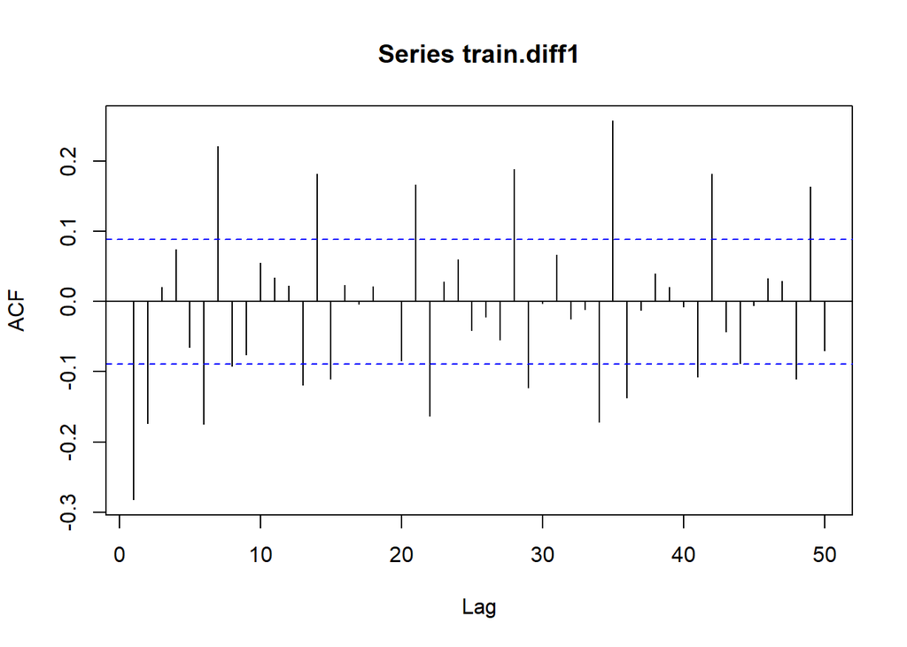

```r
acf(train.diff1,lag.max=50)
```

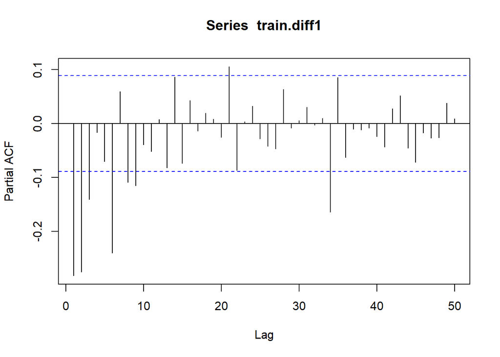

```r
pacf(train.diff1,lag.max=50)
```

ACF pada kelipatan 7 cenderung slowly tails off. kita lakukan differeincing lag 7

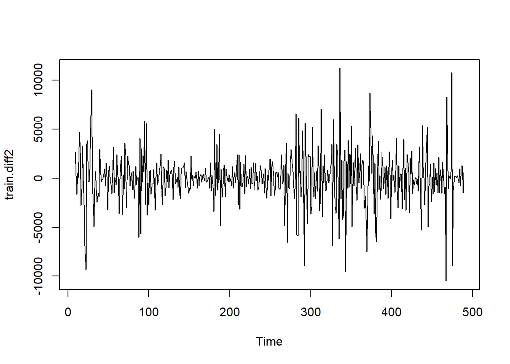

```r
train.diff2 <- diff(train.diff1,lag=7)
plot(train.diff2)
```

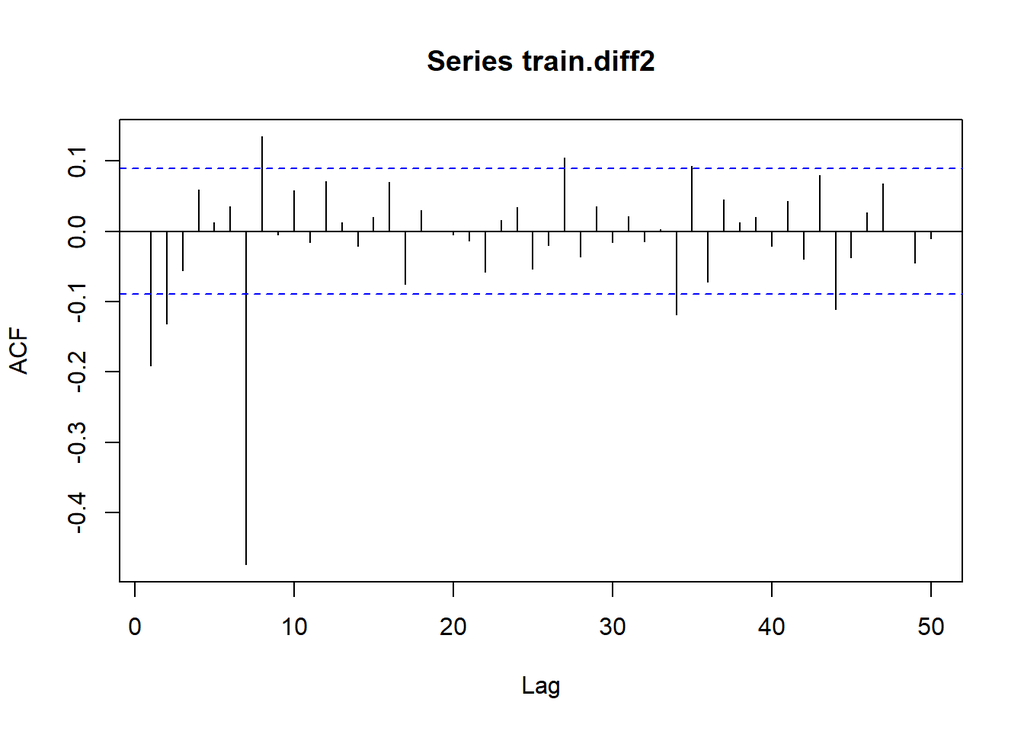

```r
acf(train.diff2,lag.max=50)
```

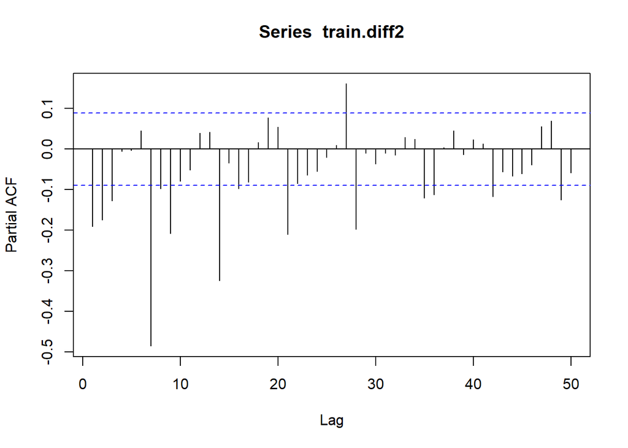

```r
pacf(train.diff2,lag.max=50)
```

```r
index.diff2 <- 1:length(train.diff2)
bc.tain.diff2 <- boxcox(train.diff2 - (min(train.diff2)-1) ~ index.diff2, lambda = seq(-2, 2, 0.001))
```

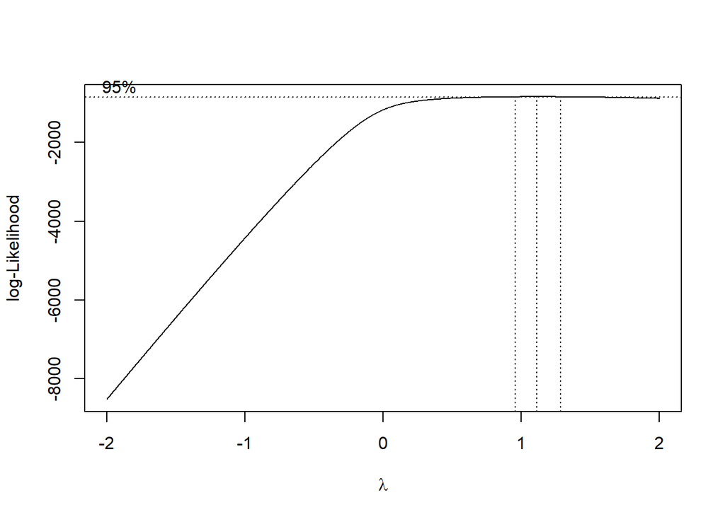

```r
bc.tain.diff2$x[which.max(bc.tain.diff2$y)]
```

```
## [1] 1.115
```

sudah mengandung 1

## Identifikasi Model

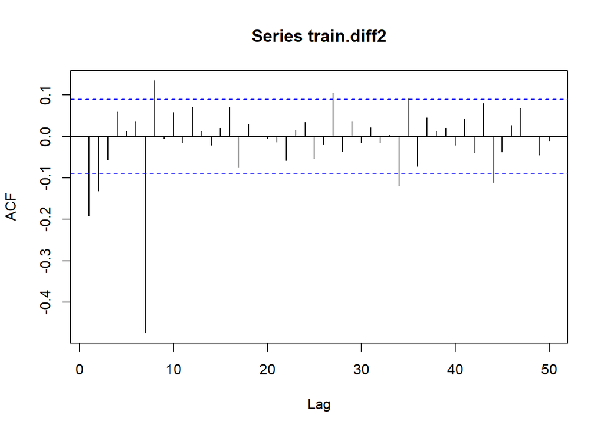

```r
acf(train.diff2,lag.max = 50)
```

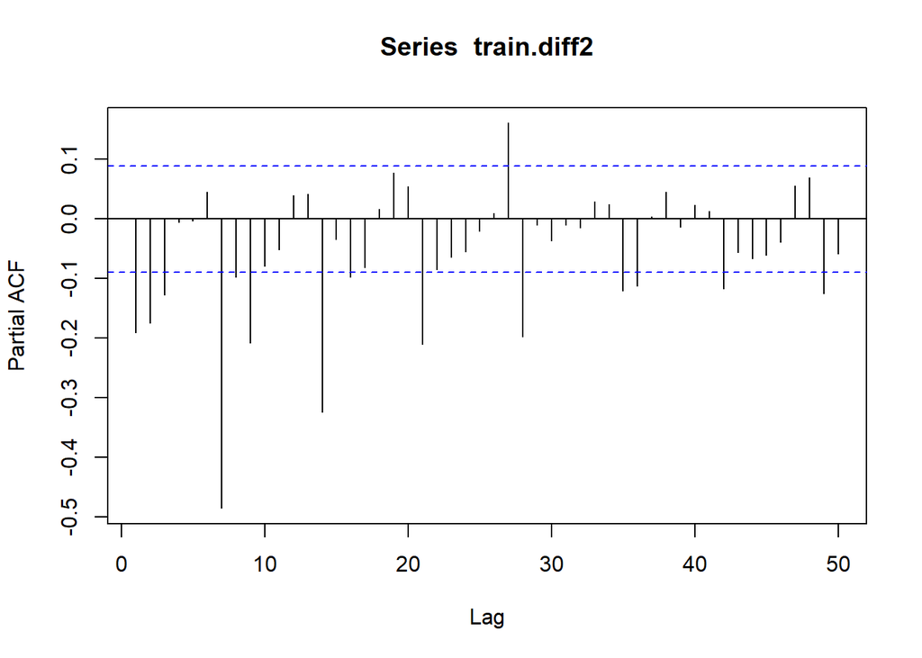

```r
pacf(train.diff2,lag.max=50)
```

```r
eacf(train.diff2)
```

```
## AR/MA
##   0 1 2 3 4 5 6 7 8 9 10 11 12 13
## 0 x x o o o o x x o o o  o  o  o
## 1 x o x o o o x x o o o  o  o  o
## 2 x x x o o o x x x o o  o  o  o
## 3 o o x o o o x x x o o  o  o  o
## 4 x o o o o o x x x x x  o  o  o
## 5 o o o o o o x x x x x  o  o  o
## 6 o o o x x x x o x x x  o  o  o
## 7 x x o o x o x x o x x  o  o  x
```

```r
auto.arima(train.diff2)
```

```
## Series: train.diff2
## ARIMA(3,0,0) with zero mean
##
## Coefficients:
##           ar1      ar2      ar3
##       -0.2467  -0.2024  -0.1267
## s.e.   0.0452   0.0457   0.0452
##
## sigma^2 = 6227421:  log likelihood = -4443.57
## AIC=8895.15   AICc=8895.23   BIC=8911.85
```

```r
model1 <- Arima(train.ts, order = c(2,1,0), seasonal = list(order = c(0,1,0), period = 7))
summary(model1)
```

```
## Series: train.ts
## ARIMA(2,1,0)(0,1,0)[7]
##
## Coefficients:
##           ar1      ar2
##       -0.2246  -0.1740
## s.e.   0.0449   0.0449
##
## sigma^2 = 6316659:  log likelihood = -4447.47
## AIC=8900.95   AICc=8901   BIC=8913.48
##
## Training set error measures:
##                    ME     RMSE      MAE       MPE     MAPE    MASE        ACF1
## Training set 1.295712 2487.465 1672.343 -1.326195 12.84417 1.05442 -0.02203939
```

```r
lmtest::coeftest(model1)
```

```
##
## z test of coefficients:
##
##      Estimate Std. Error z value  Pr(>|z|)
## ar1 -0.224591   0.044924 -4.9994 5.751e-07 ***
## ar2 -0.173956   0.044875 -3.8764  0.000106 ***
## ---
## Signif. codes:  0 '***' 0.001 '**' 0.01 '*' 0.05 '.' 0.1 ' ' 1
```

```r
model2 <- Arima(train.ts, order = c(0,1,2), seasonal = list(order = c(0,1,1), period = 7))
summary(model2)
```

```
## Series: train.ts
## ARIMA(0,1,2)(0,1,1)[7]
##
## Coefficients:
##           ma1      ma2     sma1
##       -0.3649  -0.2619  -0.9848
## s.e.   0.0437   0.0462   0.0390
##
## sigma^2 = 3080146:  log likelihood = -4286.32
## AIC=8580.64   AICc=8580.72   BIC=8597.34
##
## Training set error measures:
##                     ME     RMSE      MAE       MPE     MAPE      MASE
## Training set -95.59461 1735.182 1186.332 -2.186339 9.493358 0.7479882
##                    ACF1
## Training set 0.01514836
```

```r
lmtest::coeftest(model2)
```

```
##
## z test of coefficients:
##
##       Estimate Std. Error  z value  Pr(>|z|)
## ma1  -0.364904   0.043714  -8.3476 < 2.2e-16 ***
## ma2  -0.261867   0.046156  -5.6735 1.399e-08 ***
## sma1 -0.984769   0.039042 -25.2235 < 2.2e-16 ***
## ---
## Signif. codes:  0 '***' 0.001 '**' 0.01 '*' 0.05 '.' 0.1 ' ' 1
```

```r
model3 <- Arima(train.ts, order = c(3,1,0), seasonal = list(order = c(0,1,1), period = 7))
summary(model3)
```

```
## Series: train.ts
## ARIMA(3,1,0)(0,1,1)[7]
##
## Coefficients:
##           ar1      ar2      ar3     sma1
##       -0.3070  -0.2765  -0.1335  -0.9764
## s.e.   0.0452   0.0456   0.0450   0.0287
##
## sigma^2 = 3184238:  log likelihood = -4292.42
## AIC=8594.85   AICc=8594.98   BIC=8615.73
##
## Training set error measures:
##                     ME     RMSE      MAE       MPE     MAPE      MASE
## Training set -57.85564 1762.412 1203.752 -1.818169 9.580496 0.7589716
##                      ACF1
## Training set -0.008533591
```

```r
lmtest::coeftest(model3)
```

```
##
## z test of coefficients:
##
##       Estimate Std. Error  z value  Pr(>|z|)
## ar1  -0.307016   0.045218  -6.7897 1.123e-11 ***
## ar2  -0.276485   0.045572  -6.0670 1.303e-09 ***
## ar3  -0.133475   0.044960  -2.9688   0.00299 **
## sma1 -0.976449   0.028720 -33.9990 < 2.2e-16 ***
## ---
## Signif. codes:  0 '***' 0.001 '**' 0.01 '*' 0.05 '.' 0.1 ' ' 1
```

```r
model4 <- Arima(train.ts, order = c(3,1,2), seasonal = list(order = c(0,1,1), period = 7))
summary(model4)
```

```
## Series: train.ts
## ARIMA(3,1,2)(0,1,1)[7]
##
## Coefficients:
##          ar1      ar2     ar3      ma1     ma2     sma1
##       0.5387  -0.0635  0.0698  -0.8915  0.0227  -0.9792
## s.e.  0.4159   0.2037  0.0568   0.4151  0.3422   0.0322
##
## sigma^2 = 3071338:  log likelihood = -4283.61
## AIC=8581.23   AICc=8581.46   BIC=8610.46
##
## Training set error measures:
##                     ME     RMSE      MAE       MPE     MAPE      MASE
## Training set -107.7324 1727.254 1191.918 -2.277446 9.532212 0.7515103
##                      ACF1
## Training set -0.006297618
```

```r
lmtest::coeftest(model4)
```

```
##
## z test of coefficients:
##
##       Estimate Std. Error  z value Pr(>|z|)
## ar1   0.538721   0.415932   1.2952  0.19525
## ar2  -0.063515   0.203742  -0.3117  0.75524
## ar3   0.069823   0.056815   1.2289  0.21909
## ma1  -0.891540   0.415116  -2.1477  0.03174 *
## ma2   0.022665   0.342235   0.0662  0.94720
## sma1 -0.979223   0.032224 -30.3879  < 2e-16 ***
## ---
## Signif. codes:  0 '***' 0.001 '**' 0.01 '*' 0.05 '.' 0.1 ' ' 1
```

```r
model5 <- Arima(train.ts, order = c(0,1,3), seasonal = list(order = c(0,1,1), period = 7))
summary(model5)
```

```
## Series: train.ts
## ARIMA(0,1,3)(0,1,1)[7]
##
## Coefficients:
##           ma1      ma2      ma3    sma1
##       -0.3500  -0.2412  -0.0771  -0.985
## s.e.   0.0455   0.0473   0.0453   0.040
##
## sigma^2 = 3066257:  log likelihood = -4284.88
## AIC=8579.75   AICc=8579.88   BIC=8600.63
##
## Training set error measures:
##                     ME     RMSE      MAE       MPE    MAPE      MASE
## Training set -104.6811 1729.454 1187.757 -2.251126 9.50484 0.7488863
##                      ACF1
## Training set -0.003814044
```

```r
lmtest::coeftest(model5)
```

```
##
## z test of coefficients:
##
##       Estimate Std. Error  z value  Pr(>|z|)
## ma1  -0.349990   0.045463  -7.6984 1.378e-14 ***
## ma2  -0.241223   0.047321  -5.0976 3.439e-07 ***
## ma3  -0.077135   0.045310  -1.7024   0.08868 .
## sma1 -0.985001   0.039951 -24.6554 < 2.2e-16 ***
## ---
## Signif. codes:  0 '***' 0.001 '**' 0.01 '*' 0.05 '.' 0.1 ' ' 1
```

terbaik model 2 ARIMA(0,1,2)(0,1,1)7 - assuming acf cutoff

### Overfitting

```r
model6 <- Arima(train.ts, order = c(1,1,2), seasonal = list(order = c(0,1,1), period = 7))
summary(model6)
```

```
## Series: train.ts
## ARIMA(1,1,2)(0,1,1)[7]
##
## Coefficients:
##          ar1      ma1      ma2     sma1
##       0.3596  -0.7095  -0.0935  -0.9827
## s.e.  0.1617   0.1681   0.1067   0.0360
##
## sigma^2 = 3062722:  log likelihood = -4284.34
## AIC=8578.67   AICc=8578.8   BIC=8599.55
##
## Training set error measures:
##                     ME     RMSE      MAE       MPE     MAPE      MASE
## Training set -108.2894 1728.457 1192.758 -2.280705 9.543316 0.7520398
##                      ACF1
## Training set -0.007685476
```

```r
lmtest::coeftest(model6)
```

```
##
## z test of coefficients:
##
##       Estimate Std. Error  z value  Pr(>|z|)
## ar1   0.359627   0.161678   2.2243   0.02613 *
## ma1  -0.709512   0.168143  -4.2197 2.446e-05 ***
## ma2  -0.093489   0.106668  -0.8765   0.38078
## sma1 -0.982708   0.036037 -27.2692 < 2.2e-16 ***
## ---
## Signif. codes:  0 '***' 0.001 '**' 0.01 '*' 0.05 '.' 0.1 ' ' 1
```

```r
model7 <- Arima(train.ts, order = c(0,1,3), seasonal = list(order = c(0,1,1), period = 7))
summary(model7)
```

```
## Series: train.ts
## ARIMA(0,1,3)(0,1,1)[7]
##
## Coefficients:
##           ma1      ma2      ma3    sma1
##       -0.3500  -0.2412  -0.0771  -0.985
## s.e.   0.0455   0.0473   0.0453   0.040
##
## sigma^2 = 3066257:  log likelihood = -4284.88
## AIC=8579.75   AICc=8579.88   BIC=8600.63
##
## Training set error measures:
##                     ME     RMSE      MAE       MPE    MAPE      MASE
## Training set -104.6811 1729.454 1187.757 -2.251126 9.50484 0.7488863
##                      ACF1
## Training set -0.003814044
```

```r
lmtest::coeftest(model7)
```

```
##
## z test of coefficients:
##
##       Estimate Std. Error  z value  Pr(>|z|)
## ma1  -0.349990   0.045463  -7.6984 1.378e-14 ***
## ma2  -0.241223   0.047321  -5.0976 3.439e-07 ***
## ma3  -0.077135   0.045310  -1.7024   0.08868 .
## sma1 -0.985001   0.039951 -24.6554 < 2.2e-16 ***
## ---
## Signif. codes:  0 '***' 0.001 '**' 0.01 '*' 0.05 '.' 0.1 ' ' 1
```

```r
model8 <- Arima(train.ts, order = c(0,1,2), seasonal = list(order = c(0,1,2), period = 7))
summary(model8)
```

```
## Series: train.ts
## ARIMA(0,1,2)(0,1,2)[7]
##
## Coefficients:
##           ma1      ma2     sma1    sma2
##       -0.3655  -0.2613  -0.9925  0.0099
## s.e.   0.0438   0.0461   0.0502  0.0454
##
## sigma^2 = 3090227:  log likelihood = -4286.3
## AIC=8582.59   AICc=8582.72   BIC=8603.47
##
## Training set error measures:
##                     ME     RMSE      MAE       MPE     MAPE      MASE
## Training set -96.02967 1736.201 1187.843 -2.189937 9.505501 0.7489405
##                    ACF1
## Training set 0.01439988
```

```r
lmtest::coeftest(model8)
```

```
##
## z test of coefficients:
##
##        Estimate Std. Error  z value  Pr(>|z|)
## ma1  -0.3655070  0.0437608  -8.3524 < 2.2e-16 ***
## ma2  -0.2612708  0.0460717  -5.6710  1.42e-08 ***
## sma1 -0.9924783  0.0501523 -19.7893 < 2.2e-16 ***
## sma2  0.0099367  0.0454066   0.2188    0.8268
## ---
## Signif. codes:  0 '***' 0.001 '**' 0.01 '*' 0.05 '.' 0.1 ' ' 1
```

```r
model9 <- Arima(train.ts, order = c(0,1,2), seasonal = list(order = c(1,1,1), period = 7))
summary(model9)
```

```
## Series: train.ts
## ARIMA(0,1,2)(1,1,1)[7]
##
## Coefficients:
##           ma1      ma2     sar1     sma1
##       -0.3655  -0.2612  -0.0109  -0.9822
## s.e.   0.0438   0.0461   0.0480   0.0365
##
## sigma^2 = 3090462:  log likelihood = -4286.29
## AIC=8582.59   AICc=8582.72   BIC=8603.47
##
## Training set error measures:
##                     ME     RMSE      MAE       MPE     MAPE      MASE
## Training set -96.06095 1736.267 1187.945 -2.190151 9.506343 0.7490053
##                    ACF1
## Training set 0.01430999
```

```r
lmtest::coeftest(model9)
```

```
##
## z test of coefficients:
##
##       Estimate Std. Error  z value  Pr(>|z|)
## ma1  -0.365519   0.043765  -8.3519 < 2.2e-16 ***
## ma2  -0.261235   0.046060  -5.6716 1.415e-08 ***
## sar1 -0.010879   0.048011  -0.2266    0.8207
## sma1 -0.982199   0.036547 -26.8751 < 2.2e-16 ***
## ---
## Signif. codes:  0 '***' 0.001 '**' 0.01 '*' 0.05 '.' 0.1 ' ' 1
```

model 2 tetap terbaik 0,1,2 0,1,1 7

## Diagnostik sisaan

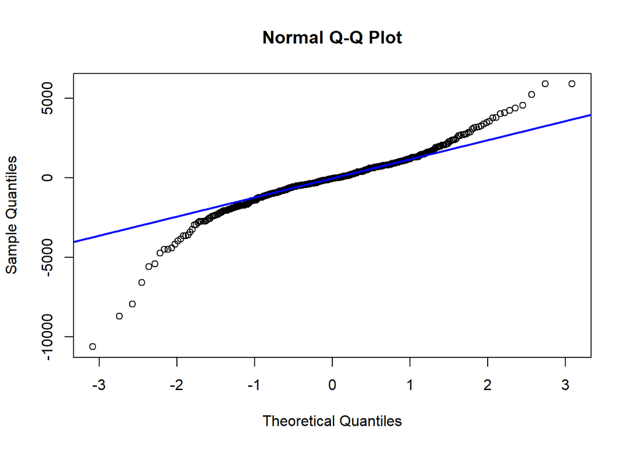

```r
sisaan <- model2$residuals
qqnorm(sisaan)
qqline(sisaan, col = "blue", lwd = 2)
```

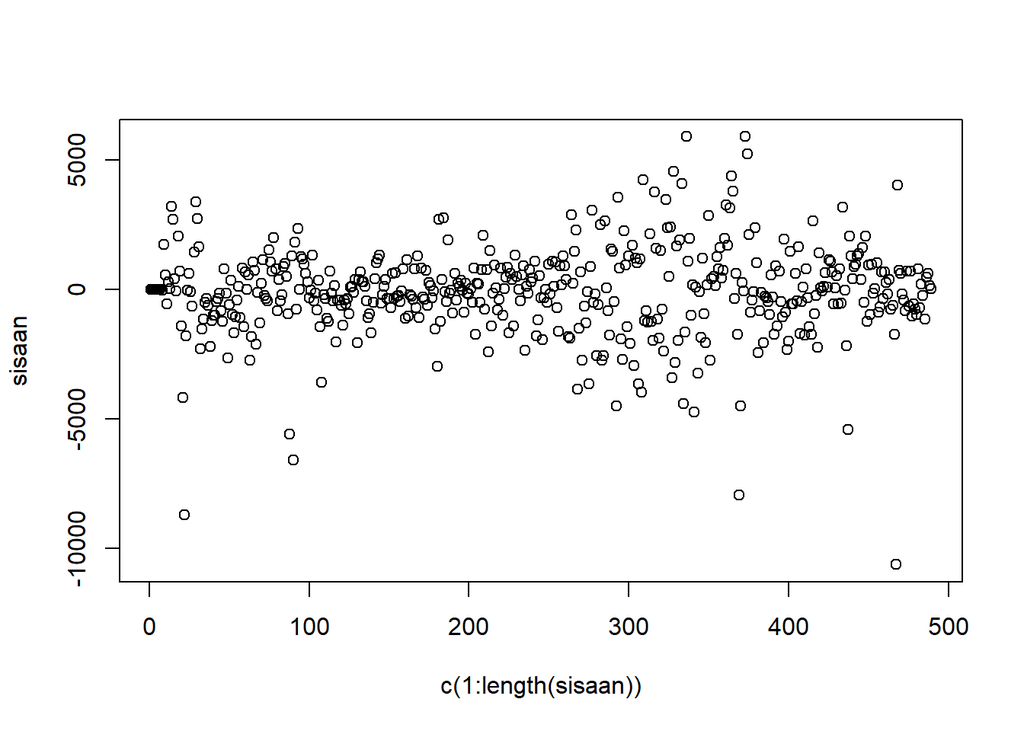

```r
plot(c(1:length(sisaan)),sisaan)
```

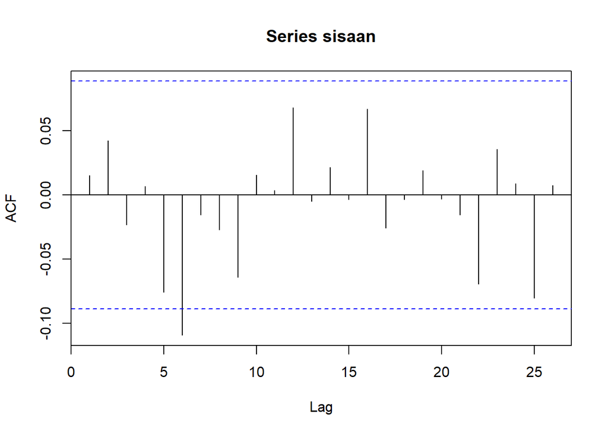

```r
acf(sisaan)
```

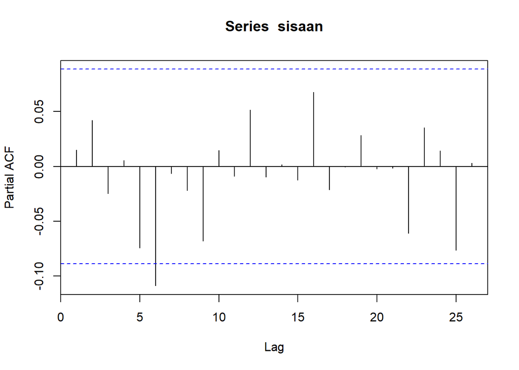

```r
pacf(sisaan)
```

```r
shapiro.test(sisaan)
```

```
##
##  Shapiro-Wilk normality test
##
## data:  sisaan
## W = 0.92659, p-value = 9.876e-15
```

```r
Box.test(sisaan, type = "Ljung-Box")
```

```
##
##  Box-Ljung test
##
## data:  sisaan
## X-squared = 0.1129, df = 1, p-value = 0.7369
```

```r
Box.test(sisaan^2, type = "Ljung-Box")
```

```
##
##  Box-Ljung test
##
## data:  sisaan^2
## X-squared = 17.314, df = 1, p-value = 3.168e-05
```

### Uji Efek ARCH LM

```r
for(i in seq(1,10,1)){
  cat("Lags: ",i,"\n")
  print(ArchTest(sisaan, lags = i)$p.value)
}
```

```
## Lags:  1
##  Chi-squared
## 3.395823e-05
## Lags:  2
## Chi-squared
##  0.00019231
## Lags:  3
##  Chi-squared
## 0.0006577363
## Lags:  4
##  Chi-squared
## 0.0005025688
## Lags:  5
##  Chi-squared
## 0.0004622866
## Lags:  6
## Chi-squared
## 0.001029559
## Lags:  7
## Chi-squared
## 0.001114558
## Lags:  8
## Chi-squared
## 0.001792222
## Lags:  9
## Chi-squared
## 0.003444502
## Lags:  10
## Chi-squared
## 0.005995997
```

## Residual Analysis

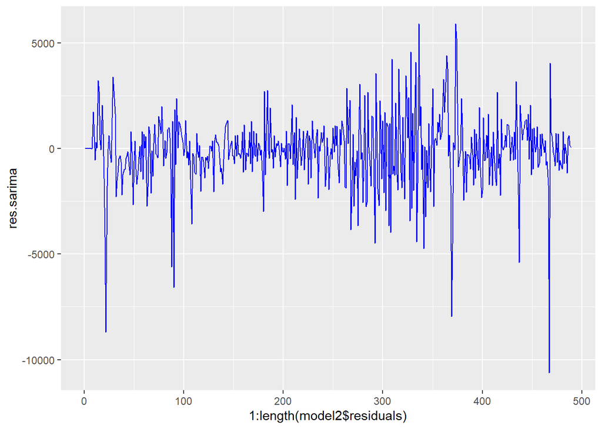

```r
#write.csv(model1$residuals, "D:\\IPB\\5\\MPDW\\project\\2 garch try\\residual_arima.csv")

res.sarima <- (model2$residuals)

ggplot()+
  geom_line(aes(x=1:length(model2$residuals), y=res.sarima), color="blue")
```

```r
write.csv(res.sarima, "D:\\IPB\\5\\MPDW\\project\\4 garch try 2\\res_sarima_fix.csv")
```

### Cek Garch White Noise

```r
et_train <- read.csv("D:\\IPB\\5\\MPDW\\project\\4 garch try 2\\et_train_90.csv")
head(et_train)
```

```
##   X   cond_vol
## 1 0   7.814178
## 2 1  43.217888
## 3 2 -28.973146
## 4 3  41.209513
## 5 4  16.965163
## 6 5  40.234408
```

```r
hasil.hybrid.et <- model2$fitted + et_train$cond_vol
```

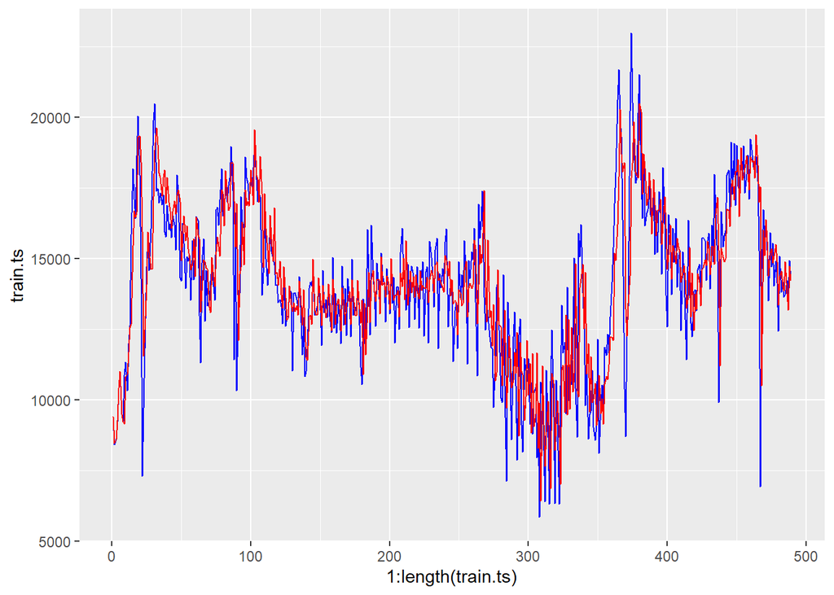

```r
ggplot()+
  geom_line(aes(x=1:length(train.ts), y=train.ts), color="blue")+
  geom_line(aes(x=1:length(hasil.hybrid.et), y=hasil.hybrid.et), color="red")
```

```r
accuracy(train.ts,model2$fitted)
```

```
##                ME     RMSE      MAE       MPE     MAPE       ACF1 Theil's U
## Test set 95.59461 1735.182 1186.332 0.1778119 8.881461 0.01514836  1.081437
```

```r
accuracy(train.ts,hasil.hybrid.et)
```

```
##                ME     RMSE      MAE       MPE     MAPE       ACF1 Theil's U
## Test set 100.3262 1733.613 1184.165 0.2192077 8.864019 0.01492398  1.078844
```

### forecast

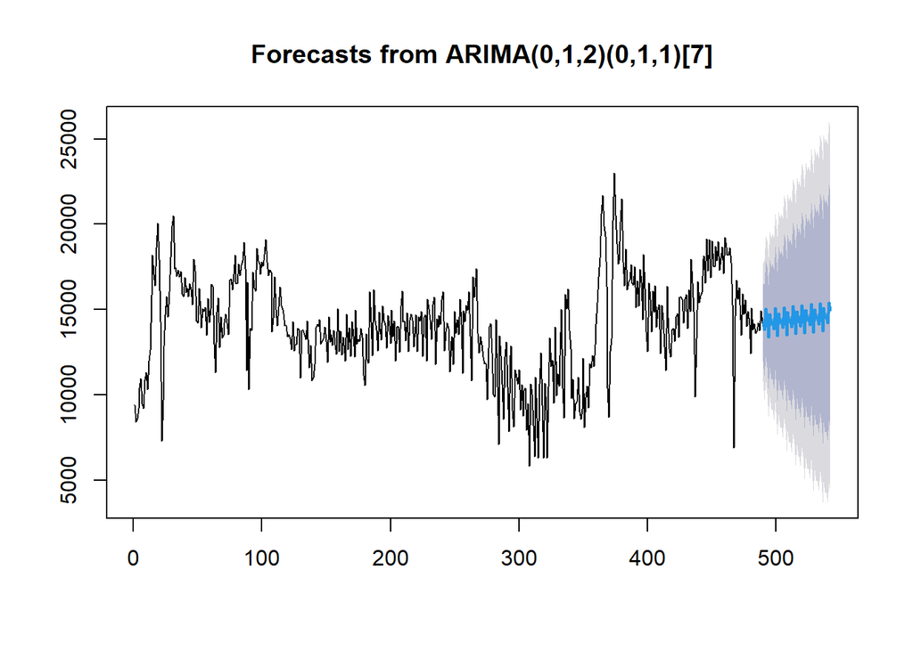

```r
forecast.model.sarima <- forecast(model2, h = length(test.ts))
plot(forecast.model.sarima)
```

```r
predict_et <- read.csv("D:\\IPB\\5\\MPDW\\project\\4 garch try 2\\predict_et_90.csv")

forecast.hybrid.et <- forecast.model.sarima$mean + predict_et$X0
```

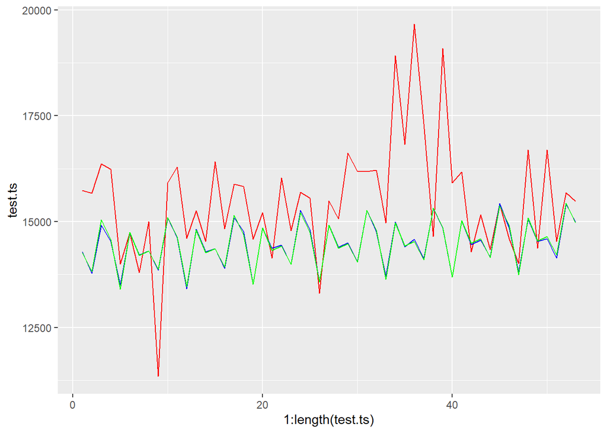

```r
ggplot()+
  geom_line(aes(x=1:length(test.ts), y=test.ts), color="red")+
  geom_line(aes(x=1:length(forecast.hybrid.et), y=forecast.hybrid.et), color="blue")+
  geom_line(aes(x=1:length(forecast.model.sarima$mean), y=forecast.model.sarima$mean), color="green")
```

```r
accuracy(ts(test.ts),ts(forecast.hybrid.et))
```

```
##                 ME    RMSE      MAE       MPE     MAPE      ACF1 Theil's U
## Test set -1026.994 1621.85 1203.284 -7.088858 8.332077 0.2676943  1.841112
```

```r
accuracy(ts(test.ts),ts(forecast.model.sarima$mean))
```

```
##                 ME     RMSE      MAE       MPE    MAPE      ACF1 Theil's U
## Test set -1027.548 1624.256 1206.846 -7.096345 8.35845 0.2673417  1.823649
```